# Reproducible Research: Peer Assessment 1

**If any of the plots are generated you could find them in the folder figures**

## Loading and preprocessing the data

Here we are going to load the data for this assignment

```r
activity<-read.csv(file = "activity.csv", sep = ",")
activity$date<-as.POSIXct(activity$date, format="%Y-%m-%d")
activity$weekdays<-weekdays(activity$date)
activity$daytype<-ifelse(activity$weekday == "sábado" | activity$weekday == "domingo", "weekend", "weekday")
head(activity)
```

```
##   steps       date interval weekdays daytype
## 1    NA 2012-10-01        0    lunes weekday
## 2    NA 2012-10-01        5    lunes weekday
## 3    NA 2012-10-01       10    lunes weekday
## 4    NA 2012-10-01       15    lunes weekday
## 5    NA 2012-10-01       20    lunes weekday
## 6    NA 2012-10-01       25    lunes weekday
```

## What is mean total number of steps taken per day?

This shows the number of steps taken per day:

```r
sums_activity<-tapply(activity$steps,activity$date,sum,na.rm=TRUE)
head(sums_activity)
```

```
## 2012-10-01 2012-10-02 2012-10-03 2012-10-04 2012-10-05 2012-10-06
##          0        126      11352      12116      13294      15420
```

Here you could see a histogram that shows the number od steps taken each day

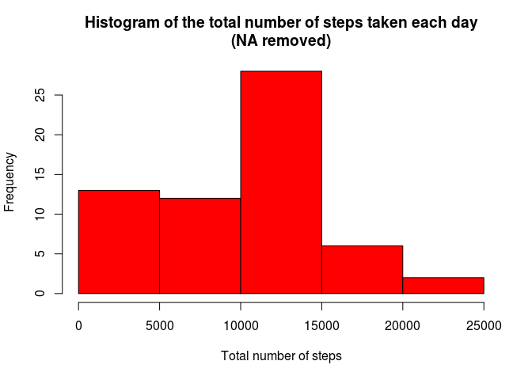

```r
hist(sums_activity, col = "red", xlab = "Total number of steps", main = "Histogram of the total number of steps taken each day\n(NA removed)")
```

Here you can see the mean and the median of the total number of steps taken per day

```r
mean(sums_activity)
```

```
## [1] 9354.23
```

```r
median(sums_activity)
```

```
## [1] 10395
```

## What is the average daily activity pattern?

Here you could see the average numver of steps done for each 5-minutes interval

```r
means_activity<-tapply(activity$steps,activity$interval,mean,na.rm=TRUE)
head(means_activity)
```

```
##         0         5        10        15        20        25
## 1.7169811 0.3396226 0.1320755 0.1509434 0.0754717 2.0943396
```

And this is the time series plot generated

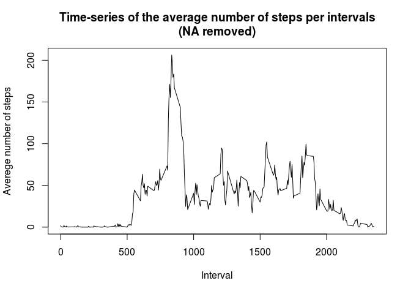

```r
plot(unique(activity$interval),means_activity, type = "l", xlab = "Interval", ylab = "Averege number of steps",
     main = "Time-series of the average number of steps per intervals\n(NA removed)")
```

Here you will see what is the five-minutes interval, on average across all the days in the dataset that contains the maximum number of steps. Also you could see it’s respective value.

```r
max_pos <- which(means_activity == max(means_activity))
means_activity[max_pos]
```

```
##      835
## 206.1698
```

## Imputing missing values

Here I could show you the total number of missing values in the dataset

```r
sum(is.na(activity$steps))
```

```
## [1] 2304
```

In the next codeblock I have replaced the the NA values by the mean of the steps attribute

```r
na_rows<-which(is.na(activity$steps))
replacing_vector<-rep(mean(activity$steps,na.rm = TRUE), times=length(na_rows))
activity[na_rows,"steps"]<-replacing_vector
head(activity)
```

```
##     steps       date interval weekdays daytype
## 1 37.3826 2012-10-01        0    lunes weekday
## 2 37.3826 2012-10-01        5    lunes weekday
## 3 37.3826 2012-10-01       10    lunes weekday
## 4 37.3826 2012-10-01       15    lunes weekday
## 5 37.3826 2012-10-01       20    lunes weekday
## 6 37.3826 2012-10-01       25    lunes weekday
```

As you could see the NA values of the first day have been changed by the mean.

Then the number of steps taken per day are calculated as I did in the first question.

```r
sums_activity2<-tapply(activity$steps,activity$date,sum,na.rm=TRUE)
head(sums_activity2)
```

```
## 2012-10-01 2012-10-02 2012-10-03 2012-10-04 2012-10-05 2012-10-06
##   10766.19     126.00   11352.00   12116.00   13294.00   15420.00
```

Then I have created the histogram that shows the number of steps taken each day but having the NA values replaced

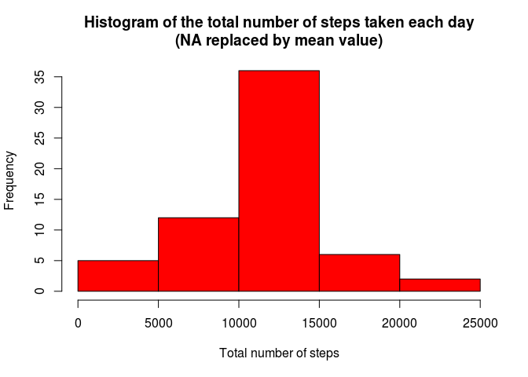

```r
hist(sums_activity2, col = "red", xlab = "Total number of steps", main = "Histogram of the total number of steps taken each day\n(NA replaced by mean value)")
```

As I did in the firs question here I show the values of the mean of the total number of steps taken per day accordint to the fact that we have the NA values replaced

```r
mean(sums_activity2)
```

```
## [1] 10766.19
```

```r
median(sums_activity2)
```

```
## [1] 10766.19
```

## Are there differences in activity patterns between weekdays and weekends?

```r
mean_data_activity<-aggregate(activity$steps, by=list(activity$interval, activity$weekday, activity$daytype), mean)
names(mean_data_activity) <- c("interval","weekday","daytype", "mean")
head(mean_data_activity)
```

```
##   interval weekday daytype     mean
## 1        0  jueves weekday 9.375844
## 2        5  jueves weekday 4.153622
## 3       10  jueves weekday 4.153622
## 4       15  jueves weekday 5.042511
## 5       20  jueves weekday 4.153622
## 6       25  jueves weekday 5.375844
```

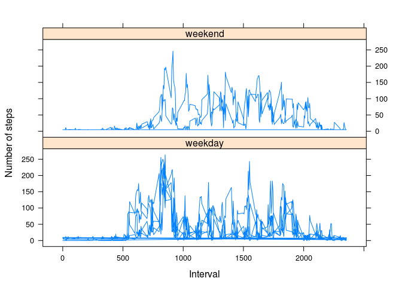

```r
library(lattice)
xyplot(mean ~ interval | daytype, mean_data_activity, type="l", xlab="Interval",  ylab="Number of steps", layout=c(1,2))
```